# What Is Shared Across CLL Omics Layers?

## The question

The CLL cohort asks a familiar multi-omics question: when transcript abundance, DNA methylation, and drug response are measured on overlapping patients, which axes of variation are genuinely shared? This vignette applies `rajiveplus` to the public Chronic Lymphocytic Leukaemia cohort from Dietrich et al. (2018) ([PMID 29227291](https://pubmed.ncbi.nlm.nih.gov/29227291/)), distributed through `BloodCancerMultiOmics2017`. The same data were used in the original MOFA2 vignette (Argelaguet et al. 2020), giving a useful point of comparison.

We use three approximately Gaussian views:

| Block | Source object | Biological meaning |
| --- | --- | --- |
| mRNA | `dds` (DESeqDataSet, 63 677 genes × 136 samples) | Transcriptional programs |
| Methylation | `methData` (RangedSummarizedExperiment, 5 000 CpGs × 196 samples) | Epigenetic state |
| Drug viability | `lpdAll` (ExpressionSet, 448 drug–dose features × 249 samples) | Pharmacological sensitivity |

> **Why no mutations block?** The MOFA2 tutorial includes somatic mutations as a fourth block using a Bernoulli likelihood. RaJIVE inherits the JIVE Gaussian assumption, so binary mutation matrices are not used as input here. IGHV mutation status and trisomy 12 instead enter as metadata for interpretation and clinical validation.

The three-way sample overlap after restricting to CLL patients is **~121 samples**.

The analysis follows five questions:

1. Which joint sources of variation are shared across all three layers?
2. Which feature weights make those axes biologically legible?
3. Do joint factors align with IGHV status or trisomy 12?
4. Which features are significant under `jackstraw_rajive()`?
5. Can joint factors predict missing IGHV status and time to treatment?

## Prerequisites

```r
if (!requireNamespace("BiocManager", quietly = TRUE))
  install.packages("BiocManager")
BiocManager::install("BloodCancerMultiOmics2017")
install.packages(c("survival", "survminer", "maxstat", "randomForest",
                   "pheatmap", "ggrepel", "patchwork"))
```

```r
library(rajiveplus)
library(ggplot2)
library(pheatmap)
```

## Data loading

```r
library(BloodCancerMultiOmics2017)
data("dds")        # DESeqDataSet: RNA-seq, 63677 genes x 136 samples
data("methData")   # RangedSummarizedExperiment: 5000 CpGs x 196 samples
data("lpdAll")     # ExpressionSet: 448 viab features + metadata x 249 samples
data("patmeta")    # Clinical metadata data.frame, rownames = patient H-IDs

cat("Raw dimensions:\n")
cat("  RNA-seq (dds):", dim(dds), "\n")
cat("  Methylation (methData):", dim(methData), "\n")
cat("  lpdAll (all features):", dim(lpdAll), "\n")
cat("  patmeta:", dim(patmeta), "\n")
```

```r
# ---- RNA-seq ----
# dds column names are integers; map to patient H-IDs via colData$PatID
rna_hids    <- SummarizedExperiment::colData(dds)[["PatID"]]
counts_mat  <- SummarizedExperiment::assay(dds)       # genes x samples
colnames(counts_mat) <- rna_hids

# log2(count + 1) normalisation; transpose to samples x genes
mrna_full   <- t(log2(counts_mat + 1))                # samples x genes

# Select top 500 highly variable genes
rv_mrna     <- apply(mrna_full, 2, var, na.rm = TRUE)
mrna_top    <- mrna_full[, order(rv_mrna, decreasing = TRUE)[1:500], drop = FALSE]

# ---- Methylation ----
# methData: features x samples; transpose to samples x CpGs
meth_full   <- t(SummarizedExperiment::assay(methData))  # samples x CpGs
rv_meth     <- apply(meth_full, 2, var, na.rm = TRUE)
meth_top    <- meth_full[, order(rv_meth, decreasing = TRUE)[1:500], drop = FALSE]

# ---- Drug viability ----
# lpdAll: filter to 'viab' feature type, then transpose
viab_idx    <- which(Biobase::fData(lpdAll)[["type"]] == "viab")
viab_full   <- t(Biobase::exprs(lpdAll)[viab_idx, ])    # samples x drug-doses
rv_viab     <- apply(viab_full, 2, var, na.rm = TRUE)
viab_top    <- viab_full[, order(rv_viab, decreasing = TRUE)[1:min(448, ncol(viab_full))],
                          drop = FALSE]

# ---- Three-way sample overlap ----
common3 <- Reduce(intersect, list(
  rownames(mrna_top),
  rownames(meth_top),
  rownames(viab_top)
))
# Restrict to CLL diagnosis
cll_flag  <- patmeta[common3, "Diagnosis"] == "CLL"
cll_flag[is.na(cll_flag)] <- FALSE
common_cll <- common3[cll_flag]
cat("Three-way overlap (CLL patients):", length(common_cll), "samples\n")

# ---- Subset and scale ----
scale_block <- function(m) {
  m_s <- scale(m, center = TRUE, scale = TRUE)
  m_s[is.nan(m_s)] <- 0
  m_s
}

blocks <- list(
  mRNA        = scale_block(mrna_top[common_cll, , drop = FALSE]),
  Methylation = scale_block(meth_top[common_cll, , drop = FALSE]),
  Drugs       = scale_block(viab_top[common_cll, , drop = FALSE])
)
meta_cc <- patmeta[common_cll, , drop = FALSE]

cat("Final block dimensions:\n")
print(lapply(blocks, dim))

saveRDS(list(blocks = blocks, meta = meta_cc),
        file.path(data_dir, "cll_preprocessed.rds"))
```

```r
pp     <- readRDS(file.path(data_dir, "cll_preprocessed.rds"))
blocks <- pp$blocks
meta   <- pp$meta
cat("Samples:", nrow(blocks[[1]]), "\n")
```

```
#> Samples: 121
```

```r
cat("Block dimensions:\n"); print(lapply(blocks, dim))
```

```
#> Block dimensions:
#> $mRNA
#> [1] 121 500
#>
#> $Methylation
#> [1] 121 500
#>
#> $Drugs
#> [1] 121 448
```

## How much signal should each block contribute?

```r
svd_list <- lapply(blocks, function(m) svd(m, nu = 0, nv = 0)$d)
saveRDS(svd_list, file.path(data_dir, "cll_svd_list.rds"))
```

```r
svd_list <- readRDS(file.path(data_dir, "cll_svd_list.rds"))
```

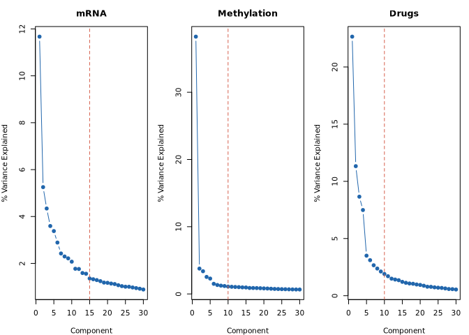

```r
block_names <- c("mRNA", "Methylation", "Drugs")
par(mfrow = c(1, 3), mar = c(4, 4, 3, 1))
for (i in seq_along(svd_list)) {
  sv  <- svd_list[[i]]
  pve <- sv^2 / sum(sv^2) * 100
  plot(seq_along(pve[1:30]), pve[1:30], type = "b", pch = 19,
       xlab = "Component", ylab = "% Variance Explained",
       main = block_names[i], col = "#2166ac")
  abline(v = c(15L, 10L, 10L)[i], col = "#d6604d", lty = 2)
}
```

```r
par(mfrow = c(1, 1))
```

The dashed red lines mark deliberately conservative initial signal ranks: **mRNA = 15**, **Methylation = 10**, and **Drugs = 10**. They define the candidate subspaces from which RaJIVE will estimate the shared structure.

## Fit RaJIVE

```r
set.seed(42)
cll_fit <- Rajive(
  blocks               = blocks,
  initial_signal_ranks = c(15L, 10L, 10L),
  full                 = TRUE,
  n_wedin_samples      = 100L,
  n_rand_dir_samples   = 100L,
  joint_rank           = NA,
  num_cores            = 12L,
  seed                 = 42L
)
saveRDS(cll_fit, file.path(data_dir, "cll_rajive_results.rds"))
```

```r
cll_fit <- readRDS(file.path(data_dir, "cll_rajive_results.rds"))
cat("Estimated joint rank:", get_joint_rank(cll_fit), "\n")
```

```
#> Estimated joint rank: 5
```

```r
print(get_all_ranks(cll_fit))
```

```
#>    block joint_rank individual_rank
#> 1 block1          5              10
#> 2 block2          5               8
#> 3 block3          5               8
```

## What did the decomposition find?

Before interpreting any factor, inspect the skeleton of the decomposition: the joint rank and the block-specific individual ranks. `summarize_components()` returns that structure as a compact table.

```r
comp_tbl <- summarize_components(ajive_output = cll_fit,
                                 summary_type = "components")
knitr::kable(comp_tbl,
             caption = "Decomposition structure: joint and individual ranks per block")
```

Decomposition structure: joint and individual ranks per block

| block | type | component | block_rank | joint_rank | n_features |
| --- | --- | --- | --- | --- | --- |
| 1 | joint | 1 | 5 | 5 | 500 |
| 1 | joint | 2 | 5 | 5 | 500 |
| 1 | joint | 3 | 5 | 5 | 500 |
| 1 | joint | 4 | 5 | 5 | 500 |
| 1 | joint | 5 | 5 | 5 | 500 |
| 1 | individual | 1 | 10 | 5 | 500 |
| 1 | individual | 2 | 10 | 5 | 500 |
| 1 | individual | 3 | 10 | 5 | 500 |
| 1 | individual | 4 | 10 | 5 | 500 |
| 1 | individual | 5 | 10 | 5 | 500 |
| 1 | individual | 6 | 10 | 5 | 500 |
| 1 | individual | 7 | 10 | 5 | 500 |
| 1 | individual | 8 | 10 | 5 | 500 |
| 1 | individual | 9 | 10 | 5 | 500 |
| 1 | individual | 10 | 10 | 5 | 500 |
| 2 | joint | 1 | 5 | 5 | 500 |
| 2 | joint | 2 | 5 | 5 | 500 |
| 2 | joint | 3 | 5 | 5 | 500 |
| 2 | joint | 4 | 5 | 5 | 500 |
| 2 | joint | 5 | 5 | 5 | 500 |
| 2 | individual | 1 | 8 | 5 | 500 |
| 2 | individual | 2 | 8 | 5 | 500 |
| 2 | individual | 3 | 8 | 5 | 500 |
| 2 | individual | 4 | 8 | 5 | 500 |
| 2 | individual | 5 | 8 | 5 | 500 |
| 2 | individual | 6 | 8 | 5 | 500 |
| 2 | individual | 7 | 8 | 5 | 500 |
| 2 | individual | 8 | 8 | 5 | 500 |
| 3 | joint | 1 | 5 | 5 | 448 |
| 3 | joint | 2 | 5 | 5 | 448 |
| 3 | joint | 3 | 5 | 5 | 448 |
| 3 | joint | 4 | 5 | 5 | 448 |
| 3 | joint | 5 | 5 | 5 | 448 |
| 3 | individual | 1 | 8 | 5 | 448 |
| 3 | individual | 2 | 8 | 5 | 448 |
| 3 | individual | 3 | 8 | 5 | 448 |
| 3 | individual | 4 | 8 | 5 | 448 |
| 3 | individual | 5 | 8 | 5 | 448 |
| 3 | individual | 6 | 8 | 5 | 448 |
| 3 | individual | 7 | 8 | 5 | 448 |
| 3 | individual | 8 | 8 | 5 | 448 |

The pairwise score plot is the RaJIVE analogue of a factor-correlation check. RaJIVE imposes orthogonality within the joint subspace, so strong residual correlation would be a warning sign rather than a biological discovery.

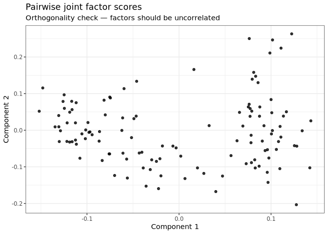

```r
plot_components(cll_fit, plot_type = "pairs", type = "joint") +
  labs(title    = "Pairwise joint factor scores",
       subtitle = "Orthogonality check — factors should be uncorrelated")
```

## Was the rank decision convincing?

AJIVE selects the joint rank by asking whether observed joint singular values clear two data-adaptive thresholds: the Wedin perturbation bound and the random-direction bound.

```r
diag_long <- extract_components(cll_fit, what = "rank_diagnostics",
                                format = "long")
knitr::kable(head(diag_long, 10),
             caption = "Top AJIVE rank-diagnostic rows")
```

Top AJIVE rank-diagnostic rows

| component_index | obs_sval | obs_sval_sq | classification | joint_rank_estimate | overall_sv_sq_threshold | wedin_cutoff | rand_cutoff | perm_cutoff | identifiability_norm |
| --- | --- | --- | --- | --- | --- | --- | --- | --- | --- |
| 1 | 1.686709 | 2.844986 | joint | 5 | 2.051256 | -997 | 2.051256 | NA | NA |
| 2 | 1.592056 | 2.534641 | joint | 5 | 2.051256 | -997 | 2.051256 | NA | NA |
| 3 | 1.514342 | 2.293232 | joint | 5 | 2.051256 | -997 | 2.051256 | NA | NA |
| 4 | 1.529288 | 2.338721 | joint | 5 | 2.051256 | -997 | 2.051256 | NA | NA |
| 5 | 1.433527 | 2.055000 | joint | 5 | 2.051256 | -997 | 2.051256 | NA | NA |
| 6 | 1.364215 | 1.861084 | nonjoint | 5 | 2.051256 | -997 | 2.051256 | NA | NA |
| 7 | 1.321094 | 1.745288 | nonjoint | 5 | 2.051256 | -997 | 2.051256 | NA | NA |
| 8 | 1.258145 | 1.582929 | nonjoint | 5 | 2.051256 | -997 | 2.051256 | NA | NA |
| 9 | 1.248191 | 1.557981 | nonjoint | 5 | 2.051256 | -997 | 2.051256 | NA | NA |
| 10 | 1.147339 | 1.316387 | nonjoint | 5 | 2.051256 | -997 | 2.051256 | NA | NA |

The composite diagnostic plot puts the evidence side by side: bound distributions, per-block singular values, and the final threshold decision.

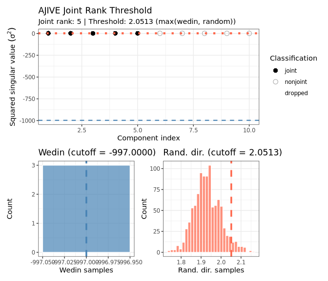

```r
plot_components(cll_fit, plot_type = "ajive_diagnostic") +
  labs(title = "CLL AJIVE full diagnostic")
```

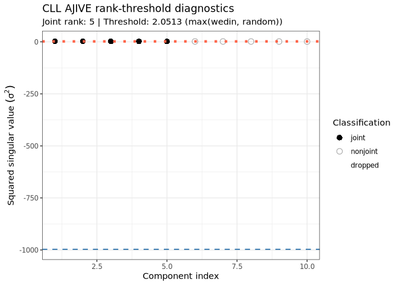

```r
plot_components(cll_fit, plot_type = "rank_threshold") +
  labs(title = "CLL AJIVE rank-threshold diagnostics")
```

```r
diag_tbl <- summarize_components(ajive_output = cll_fit,
                                 summary_type = "diagnostics")
knitr::kable(diag_tbl, digits = 4,
             caption = "AJIVE rank-selection diagnostics summary")
```

AJIVE rank-selection diagnostics summary

| component_index | obs_sval | obs_sval_sq | classification | joint_rank_estimate | overall_sv_sq_threshold | wedin_cutoff | rand_cutoff | perm_cutoff | identifiability_norm |
| --- | --- | --- | --- | --- | --- | --- | --- | --- | --- |
| 1 | 1.6867 | 2.8450 | joint | 5 | 2.0513 | -997 | 2.0513 | NA | NA |
| 2 | 1.5921 | 2.5346 | joint | 5 | 2.0513 | -997 | 2.0513 | NA | NA |
| 3 | 1.5143 | 2.2932 | joint | 5 | 2.0513 | -997 | 2.0513 | NA | NA |
| 4 | 1.5293 | 2.3387 | joint | 5 | 2.0513 | -997 | 2.0513 | NA | NA |
| 5 | 1.4335 | 2.0550 | joint | 5 | 2.0513 | -997 | 2.0513 | NA | NA |
| 6 | 1.3642 | 1.8611 | nonjoint | 5 | 2.0513 | -997 | 2.0513 | NA | NA |
| 7 | 1.3211 | 1.7453 | nonjoint | 5 | 2.0513 | -997 | 2.0513 | NA | NA |
| 8 | 1.2581 | 1.5829 | nonjoint | 5 | 2.0513 | -997 | 2.0513 | NA | NA |
| 9 | 1.2482 | 1.5580 | nonjoint | 5 | 2.0513 | -997 | 2.0513 | NA | NA |
| 10 | 1.1473 | 1.3164 | nonjoint | 5 | 2.0513 | -997 | 2.0513 | NA | NA |

## Which clinical labels follow the joint factors?

Next we test whether joint scores line up with clinical variables. These p-values are exploratory because the score-estimation uncertainty is not propagated in this section.

```r
assoc_ighv <- associate_components(
  ajive_output = cll_fit,
  metadata     = meta,
  variable     = "IGHV",
  mode         = "categorical",
  type         = "joint"
)
knitr::kable(assoc_ighv, digits = 4,
             caption = "Association: joint factors vs IGHV mutation status")
```

Association: joint factors vs IGHV mutation status

| variable | component | stat | p_value | p_adj | method |
| --- | --- | --- | --- | --- | --- |
| IGHV | 1 | 74.7499 | 0.0000 | 0.0000 | kruskal |
| IGHV | 2 | 1.1282 | 0.2882 | 0.3602 | kruskal |
| IGHV | 3 | 1.3754 | 0.2409 | 0.3602 | kruskal |
| IGHV | 4 | 1.4445 | 0.2294 | 0.3602 | kruskal |
| IGHV | 5 | 0.6219 | 0.4303 | 0.4303 | kruskal |

```r
if ("trisomy12" %in% colnames(meta)) {
  assoc_t12 <- associate_components(
    ajive_output = cll_fit,
    metadata     = meta,
    variable     = "trisomy12",
    mode         = "categorical",
    type         = "joint"
  )
  knitr::kable(assoc_t12, digits = 4,
               caption = "Association: joint factors vs trisomy 12 status")
} else {
  assoc_t12 <- NULL
  message("trisomy12 metadata not present in cached CLL object; skipping this association.")
}
```

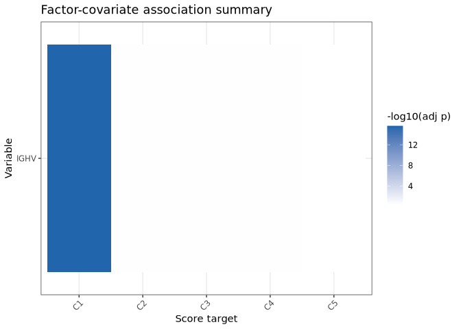

```r
# associate_components() already sets a 'variable' column; just rbind
assoc_combined <- do.call(rbind, Filter(Negate(is.null),
                                        list(assoc_ighv, assoc_t12)))
plot_components(assoc_results = assoc_combined,
                plot_type     = "association") +
  labs(title = "Factor-covariate association summary")
```

### Does the rank survive resampling?

```r
stab_rank <- assess_stability(
  ajive_output          = cll_fit,
  blocks                = blocks,
  initial_signal_ranks  = c(15L, 10L, 10L),
  target                = "joint_rank",
  B                     = 20L,
  sample_frac           = 0.8,
  num_cores             = 2L,
  seed                  = 43L
)
saveRDS(stab_rank, file.path(data_dir, "cll_stability.rds"))
```

```r
stab_path <- file.path(data_dir, "cll_stability.rds")
if (file.exists(stab_path)) {
  stab_rank <- readRDS(stab_path)
  knitr::kable(as.data.frame(stab_rank$rank_table),
               col.names = c("Joint rank", "Frequency"),
               caption   = "Bootstrap joint-rank stability (B = 20)")
} else {
  message("cll_stability.rds not found; set run_heavy = TRUE to regenerate this table.")
}
```

[output not shown]

## Where is the variation?

The variance decomposition is the high-level map of the fit. It shows whether each omics layer is dominated by shared joint structure, layer-specific individual structure, or residual variation.

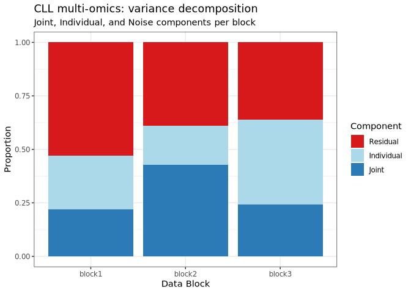

```r
plot_variance_explained(cll_fit, blocks) +
  labs(title    = "CLL multi-omics: variance decomposition",
       subtitle = "Joint, Individual, and Noise components per block") +
  theme_bw()
```

```r
ve_tbl <- summarize_components(ajive_output = cll_fit,
                               blocks       = blocks,
                               summary_type = "variance")
knitr::kable(ve_tbl, digits = 2,
             caption = "Variance explained by component type per block (%)")
```

Variance explained by component type per block (%)

| Joint | Indiv | Resid |
| --- | --- | --- |
| 0.22 | 0.25 | 0.53 |
| 0.43 | 0.18 | 0.39 |
| 0.24 | 0.40 | 0.36 |

```r
vp <- joint_variance_partition(cll_fit, blocks)
top_joint_var <- vp[order(vp$joint_prop, decreasing = TRUE),
                    c("block", "feature", "joint_prop",
                      "individual_prop", "residual_prop")]
knitr::kable(head(top_joint_var, 10), digits = 3,
             caption = "Features with the largest joint variance proportion")
```

Features with the largest joint variance proportion

|  | block | feature | joint_prop | individual_prop | residual_prop |
| --- | --- | --- | --- | --- | --- |
| 871 | Methylation | cg07629149 | 0.880 | 0.050 | 0.070 |
| 590 | Methylation | cg03462096 | 0.848 | 0.066 | 0.087 |
| 688 | Methylation | cg05213414 | 0.837 | 0.054 | 0.109 |
| 516 | Methylation | cg20782816 | 0.835 | 0.059 | 0.106 |
| 619 | Methylation | cg21394039 | 0.826 | 0.062 | 0.112 |
| 523 | Methylation | cg11181763 | 0.820 | 0.064 | 0.116 |
| 582 | Methylation | cg11090458 | 0.819 | 0.029 | 0.153 |
| 707 | Methylation | cg00148025 | 0.817 | 0.049 | 0.134 |
| 552 | Methylation | cg26441291 | 0.817 | 0.033 | 0.150 |
| 505 | Methylation | cg23844018 | 0.815 | 0.086 | 0.099 |

## What do the joint factors mean?

### Factor 1 vs Factor 2: IGHV status

```r
joint_sc <- as.data.frame(get_joint_scores(cll_fit))
colnames(joint_sc) <- paste0("Factor", seq_len(ncol(joint_sc)))
rownames(joint_sc) <- rownames(blocks[[1]])

common_ids <- intersect(rownames(joint_sc), rownames(meta))
joint_sc_m <- joint_sc[common_ids, , drop = FALSE]
meta_m     <- meta[common_ids, , drop = FALSE]
```

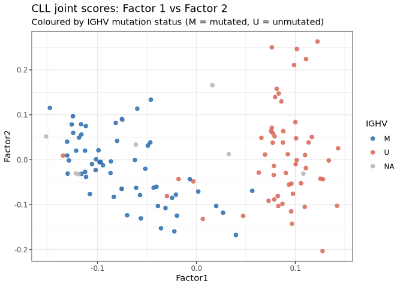

```r
nf <- min(2, ncol(joint_sc_m))
plot_df <- data.frame(joint_sc_m[, 1:nf, drop = FALSE],
                      IGHV = factor(meta_m$IGHV))
colnames(plot_df)[1:2] <- c("Factor1", "Factor2")

ggplot(plot_df, aes(x = Factor1, y = Factor2, colour = IGHV)) +
  geom_point(size = 2, alpha = 0.8) +
  scale_colour_manual(values = c("M" = "#2166ac", "U" = "#d6604d"),
                      na.value = "grey70") +
  labs(title    = "CLL joint scores: Factor 1 vs Factor 2",
       subtitle = "Coloured by IGHV mutation status (M = mutated, U = unmutated)",
       colour   = "IGHV") +
  theme_bw()
```

### Factor 1 vs Factor 3: IGHV status and trisomy 12, when available

This plot mirrors the central MOFA2 CLL display: a low-dimensional map of patients and molecular subgroups. Factor 1 is checked for the IGHV mutated (M) versus unmutated (U) split; Factor 3, when present, is checked for trisomy 12 when that metadata column is available in the cached cohort object.

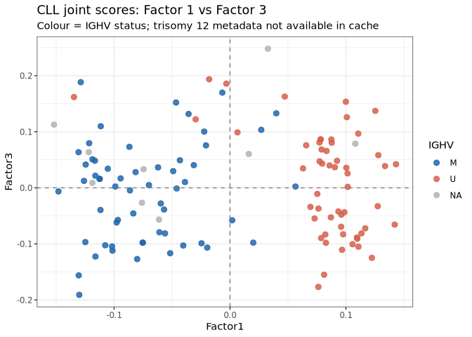

```r
if (ncol(joint_sc_m) >= 3) {
  plot_df2 <- data.frame(
    Factor1 = joint_sc_m[["Factor1"]],
    Factor3 = joint_sc_m[["Factor3"]],
    IGHV    = factor(meta_m$IGHV)
  )
  if ("trisomy12" %in% colnames(meta_m))
    plot_df2$Trisomy12 <- factor(meta_m$trisomy12)

  p_f13 <- ggplot(plot_df2, aes(x = Factor1, y = Factor3, colour = IGHV))
  if ("Trisomy12" %in% colnames(plot_df2)) {
    p_f13 <- p_f13 + aes(shape = Trisomy12) +
      scale_shape_manual(values = c("0" = 16, "1" = 17), na.value = 4)
  }
  p_f13 +
    geom_point(size = 2.5, alpha = 0.85) +
    scale_colour_manual(values = c("M" = "#2166ac", "U" = "#d6604d"),
                        na.value = "grey70") +
    geom_hline(yintercept = 0, linetype = "dashed", colour = "grey50") +
    geom_vline(xintercept = 0, linetype = "dashed", colour = "grey50") +
    labs(title    = "CLL joint scores: Factor 1 vs Factor 3",
         subtitle = if ("Trisomy12" %in% colnames(plot_df2))
           "Colour = IGHV status; shape = trisomy 12 (1 = present)"
         else
           "Colour = IGHV status; trisomy 12 metadata not available in cache",
         colour   = "IGHV", shape = "Trisomy12") +
    theme_bw()
} else {
  message("Joint rank < 3; Factor 1 vs Factor 3 plot skipped.")
}
```

### Factor–covariate correlation heatmap

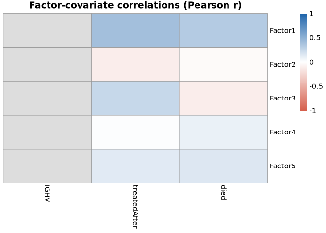

```r
covariates <- intersect(c("IGHV", "treatedAfter", "died", "trisomy12"),
                        colnames(meta_m))
cov_vals   <- meta_m[, covariates, drop = FALSE]
n_factors  <- ncol(joint_sc_m)

cor_mat <- matrix(NA, nrow = n_factors, ncol = ncol(cov_vals),
                  dimnames = list(colnames(joint_sc_m), covariates))
for (fi in seq_len(n_factors)) {
  for (ci in seq_along(covariates)) {
    cv <- suppressWarnings(as.numeric(cov_vals[[ci]]))
    if (sum(!is.na(cv)) > 5)
      cor_mat[fi, ci] <- cor(joint_sc_m[[fi]], cv, use = "complete.obs")
  }
}

pheatmap(cor_mat,
         cluster_rows = FALSE, cluster_cols = FALSE,
         color    = colorRampPalette(c("#d6604d", "white", "#2166ac"))(100),
         breaks   = seq(-1, 1, length.out = 101),
         main     = "Factor-covariate correlations (Pearson r)",
         fontsize = 11)
```